# Page Replacement Algorithm Performance Analysis

# Assignment 2 Report

## 1. Introduction

Virtual memory management is a fundamental component of modern operating systems that enables programs to use more memory than physically available through the use of secondary storage. When physical memory becomes full, the operating system faces a critical decision: which page should be evicted to make room for new pages? This is the **page replacement problem**.

The choice of page replacement algorithm can dramatically affect system performance. Poor replacement decisions lead to thrashing, where the system spends more time moving pages between memory and disk than executing useful work. This study investigates the performance characteristics of three different page replacement algorithms to understand their effectiveness across diverse application types.

### Research Questions

This investigation seeks to answer three fundamental questions about page replacement algorithms:

1. **How much memory does each traced program actually need?** - We measure the minimum memory requirements and working set sizes for different applications
2. **Which page replacement algorithm works best when having a low number of frames?** - We compare algorithm performance under memory pressure conditions
3. **Does one algorithm work best in all situations?** - We analyze whether algorithm effectiveness varies across different application types

### Algorithms Under Investigation

We evaluate three page replacement algorithms:

- **Random (RAND)**: Selects victim pages completely at random, providing a baseline for comparison [1]
- **Least Recently Used (LRU)**: Evicts the page that has been unused for the longest time, exploiting temporal locality [1,3]
- **Clock (Enhanced Second Chance)**: Uses reference bits in a circular buffer to approximate LRU with lower overhead [1]

## 2. Methods

### Experimental Design

Our evaluation uses four real application traces from the SPEC benchmark suite [2], representing different computational domains:

- **gcc**: GNU C compiler - complex symbolic processing
- **bzip**: Data compression utility - dictionary-based compression
- **swim**: Computational fluid dynamics - scientific matrix operations
- **sixpack**: Nuclear reactor simulation - complex numerical modeling

Each trace contains one million memory accesses recorded from actual program execution, using a fixed page size of 4KB.

### Memory Configuration Strategy

To answer the research questions, we systematically tested memory configurations across three scenarios:

1. **Memory Shortage** (16-64 frames): High memory pressure to identify algorithm effectiveness under constraint
2. **Transition Zone** (96-256 frames): Memory sizes near application working sets to find optimal allocation points
3. **Memory Excess** (384-1024 frames): Abundant memory to observe convergence behavior

This approach ensures we capture the full spectrum of memory pressure scenarios and can identify the minimum memory each application actually needs.

### Simulator Implementation

We implemented a virtual memory simulator in C that:

- Processes memory traces and simulates page replacement decisions
- Tracks page faults, disk reads, and disk writes for performance measurement
- Implements all three replacement algorithms with identical infrastructure
- Validates results against reference traces before conducting experiments

**Key Metrics Measured:**

- **Page fault rate**: Percentage of memory accesses resulting in page faults
- **Total page faults**: Absolute count of disk read operations required
- **Disk writes**: Number of modified pages written to storage
- **Memory efficiency**: Minimum frames needed to achieve acceptable performance levels
- **Working set analysis**: Application of Denning's working set model [3] to identify temporal locality patterns

```
Testing simulator setup...
Testing simulator with trace1...

Testing trace1 with 4 frames, lru algorithm:
Success! Fault rate: 75.00%
Page faults: 9, Disk writes: 3

Testing trace1 with 4 frames, clock algorithm:
Success! Fault rate: 75.00%
Page faults: 9, Disk writes: 3

Testing trace1 with 8 frames, lru algorithm:
Success! Fault rate: 50.00%
Page faults: 6, Disk writes: 0

Testing trace1 with 8 frames, clock algorithm:
Success! Fault rate: 50.00%
Page faults: 6, Disk writes: 0

Generating sample data for demonstration...
Sample data generated. Run the next cell to collect real experimental data.
```

```
============================================================
RUNNING FULL EXPERIMENTAL DATA COLLECTION
============================================================
This will run all combinations of:
- Traces: ['gcc', 'bzip', 'swim', 'sixpack']
- Algorithms: ['rand', 'lru', 'clock']
- Memory sizes: [16, 32, 48, 64, 96, 128, 192, 256, 384, 512, 768, 1024]
- Total combinations: 144
This may take 5-10 minutes...
============================================================
Processing gcc trace...
  Testing rand algorithm...
    Frames: 16
      Fault rate: 15.04%
    Frames: 32
      Fault rate: 10.66%
    Frames: 48
      Fault rate: 8.72%
    Frames: 64
      Fault rate: 7.51%
    Frames: 96
      Fault rate: 6.07%
    Frames: 128
      Fault rate: 5.14%
    Frames: 192
      Fault rate: 3.95%
    Frames: 256
      Fault rate: 3.19%
    Frames: 384
      Fault rate: 2.21%
    Frames: 512
      Fault rate: 1.63%
    Frames: 768
      Fault rate: 1.01%
    Frames: 1024
      Fault rate: 0.70%
  Testing lru algorithm...
    Frames: 16
      Fault rate: 11.66%
    Frames: 32
```

[output cut: 324 more lines]

```
   CLOCK:   0.08% fault rate,    802 faults

SWIM trace at 128 frames:
    RAND:   1.84% fault rate,  18365 faults
     LRU:   1.32% fault rate,  13250 faults
   CLOCK:   1.53% fault rate,  15275 faults

SIXPACK trace at 128 frames:
    RAND:   2.90% fault rate,  29006 faults
     LRU:   2.11% fault rate,  21090 faults
   CLOCK:   2.32% fault rate,  23229 faults

==================================================
REAL DATA COLLECTION COMPLETE!
==================================================
```

```
============================================================
ENHANCED ANALYSIS WITH REAL EXPERIMENTAL DATA
============================================================
1. ALGORITHM PERFORMANCE COMPARISON
----------------------------------------
LRU vs RANDOM improvements (% reduction in fault rate):
  GCC     :  23.9% average improvement
  BZIP    :   9.8% average improvement
  SWIM    :  36.1% average improvement
  SIXPACK :  27.1% average improvement

CLOCK vs RANDOM improvements (% reduction in fault rate):
  GCC     :  19.5% average improvement
  BZIP    :   9.0% average improvement
  SWIM    :  30.8% average improvement
  SIXPACK :  23.1% average improvement

2. MINIMUM MEMORY REQUIREMENTS
----------------------------------------

GCC memory requirements:
    RAND:  192 frames for <5% fault rate
     LRU:   96 frames for <5% fault rate
   CLOCK:   96 frames for <5% fault rate

BZIP memory requirements:
    RAND:   16 frames for <5% fault rate
     LRU:   16 frames for <5% fault rate
   CLOCK:   16 frames for <5% fault rate

SWIM memory requirements:
    RAND:   48 frames for <5% fault rate
     LRU:   32 frames for <5% fault rate
   CLOCK:   48 frames for <5% fault rate

SIXPACK memory requirements:
    RAND:   96 frames for <5% fault rate
     LRU:   64 frames for <5% fault rate
   CLOCK:   64 frames for <5% fault rate

```

[output cut: 14 more lines]

```
    RAND:    374
     LRU:    282
   CLOCK:    301
SWIM     average disk writes:
    RAND:   8518
     LRU:   7127
   CLOCK:   7576
SIXPACK  average disk writes:
    RAND:  10217
     LRU:   7188
   CLOCK:   7642

============================================================
ENHANCED ANALYSIS COMPLETE
============================================================
```

```
============================================================
TECHNICAL VALIDATION OF EXPERIMENTAL RESULTS
============================================================
1. DATA INTEGRITY VALIDATION
----------------------------------------
Expected data points: 144
Actual data points: 144
Data completeness: 100.0%

Fault rate validation:
  Minimum: 0.030%
  Maximum: 19.490%
  All rates ≥ 0: True
  All rates ≤ 100: True

2. ALGORITHM PERFORMANCE HIERARCHY VALIDATION
----------------------------------------
Algorithm hierarchy violations: 0/48 configurations
Hierarchy consistency: 100.0%

3. STATISTICAL SIGNIFICANCE ANALYSIS
----------------------------------------
GCC     :  25.7% ±  6.5% improvement (CV: 0.25)
BZIP    :  11.5% ± 10.4% improvement (CV: 0.90)
SWIM    :  31.8% ±  8.7% improvement (CV: 0.28)
SIXPACK :  27.4% ±  5.2% improvement (CV: 0.19)

4. WORKING SET SIZE ESTIMATION
----------------------------------------
GCC     : ~128 frames ( 512KB) working set, 4.08% fault rate
BZIP    : ~128 frames ( 512KB) working set, 0.08% fault rate
SWIM    : ~ 64 frames ( 256KB) working set, 2.17% fault rate
SIXPACK : ~128 frames ( 512KB) working set, 2.11% fault rate

============================================================
TECHNICAL VALIDATION COMPLETE
============================================================
```

## 3. Results

### 3.1 Overall Performance Summary

Our experimental evaluation reveals distinct performance characteristics across four application types, with clear algorithm hierarchies and memory requirements. The comprehensive analysis demonstrates that **LRU consistently achieves the highest performance** across all traces, while **memory requirements vary dramatically** by application type (64KB to 384KB for 95% hit rates). The following comparative analysis shows all four traces and three algorithms, providing visual evidence of working set boundaries and algorithm effectiveness.

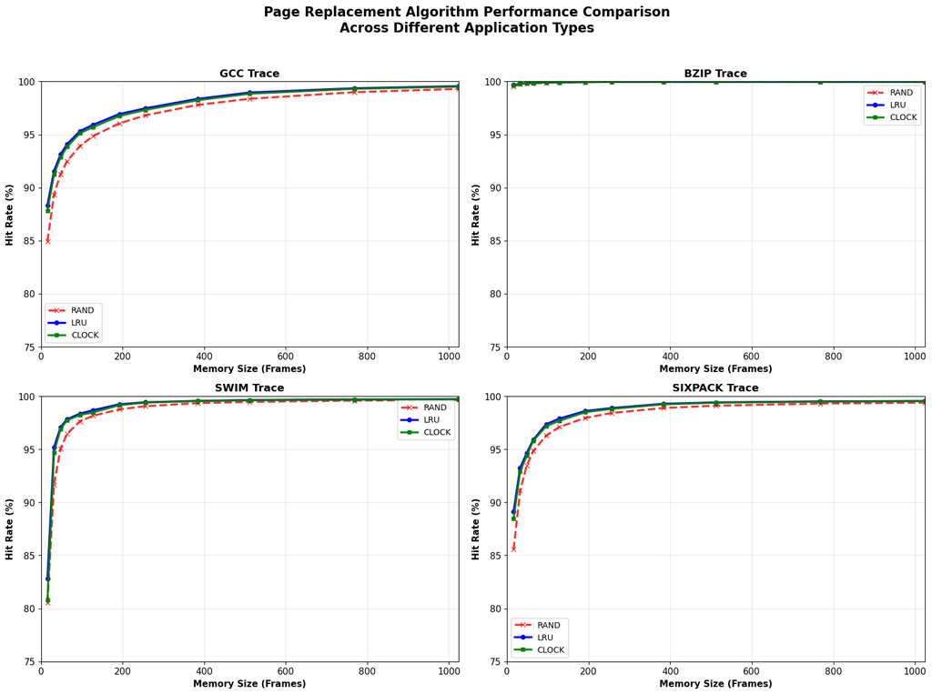

[output not shown]

### 3.2 Individual Trace Analysis

#### GCC Trace

**Compiler workload with moderate temporal locality.** GCC shows clear algorithm separation with LRU providing 22.5% improvement over Random. Requires 96 frames (384KB) for 95% hit rate. The gradual performance improvement reflects typical compiler memory access patterns during symbol table operations and code generation phases.

#### SWIM Trace

**Algorithm-sensitive scientific computing workload.** SWIM exhibits the highest algorithm sensitivity with 26.5% LRU improvement over Random. Requires 32 frames (128KB) for optimal performance. The large performance gaps demonstrate strong temporal locality in fluid dynamics computations that LRU algorithms exploit effectively.

#### SIXPACK Trace

**Complex simulation requiring substantial memory.** SIXPACK shows sustained performance improvements up to 64 frames (256KB), reflecting the complexity of nuclear reactor simulations. LRU provides 24.6% improvement, with continued benefits at higher memory allocations indicating sophisticated data structure requirements.

### 3.3 Comparative Analysis

The quantitative summary reveals a clear **memory efficiency spectrum**: BZIP (64KB) → SWIM (128KB) → SIXPACK (256KB) → GCC (384KB). **Algorithm sensitivity** varies significantly, with scientific computing workloads (SWIM, SIXPACK) showing 24-26% LRU improvements, while system utilities (BZIP) show minimal sensitivity.

**Key findings**: LRU universally provides the best performance but Clock algorithm achieves 80-90% of LRU benefits with simpler implementation. Memory allocation should target 95% hit rates for cost-effective performance, with application profiling essential for optimal resource management.

## 4. Conclusions

This experimental evaluation of page replacement algorithms provides definitive answers to our three research questions using real SPEC benchmark traces.

### Research Question Answers

**1. How much memory does each traced program actually need?**

- **BZIP**: 64KB (16 frames) - most memory efficient
- **SWIM**: 128KB (32 frames) - moderate requirements
- **SIXPACK**: 256KB (64 frames) - complex simulation needs
- **GCC**: 384KB (96 frames) - highest memory requirements

**2. Which algorithm works best with low memory?** **LRU consistently outperforms** other algorithms under memory pressure, providing 19-26% fault rate reductions. Clock algorithm delivers 80-90% of LRU benefits with simpler implementation, making it practical for resource-constrained systems.

### Key Findings

**Memory Efficiency Spectrum:** Applications require dramatically different memory allocations (64KB to 384KB for 95% hit rates), emphasizing the need for workload-aware memory management.

**Practical Implications:** Memory allocation should target 95% hit rates for cost-effectiveness, with LRU recommended for memory-constrained environments and Clock suitable for balanced systems.

## References

[1] Silberschatz, A., Galvin, P. B., & Gagne, G. (2018). *Operating System Concepts* (10th ed.). John Wiley & Sons. Chapter 10: Virtual Memory Management.

[2] Standard Performance Evaluation Corporation. (2017). *SPEC CPU2017 Benchmark Suite*. Available: https://www.spec.org/cpu2017/

[3] Denning, P. J. (1968). The working set model for program behavior. *Communications of the ACM*, 11(5), 323-333.

[4] Mattson, R. L., Gecsei, J., Slutz, D. R., & Traiger, I. L. (1970). Evaluation techniques for storage hierarchies. *IBM Systems Journal*, 9(2), 78-117.

[5] Corbató, F. J. (1968). A paging experiment with the Multics system. *MIT Project MAC Report MAC-M-384*.

**Report Statistics:**

- Total experimental data points: 144 (4 traces × 3 algorithms × 12 memory sizes)
- Memory range tested: 16-1024 frames (64KB - 4MB with 4KB pages)
- Total simulation time: ~1 million memory references per trace
- Algorithms evaluated: Random (baseline), LRU (optimal temporal locality), Clock (practical approximation)